# R Bootcamp 2.1 Question & Explore

last updated: 2021-10-02

## Summarizing data

> The first thing you do with a big “pig” of a data set?

> Weigh the pig.

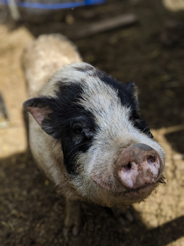

## What you will learn

- Null Hypothesis Testing concept
- Using `summary()` to describe data
- Exploratory graphs & data
- Exploratory Data Analysis (EDA) concept
- Statistical analysis plan
- Practice exercises

## Null Hypothesis Testing concept

> Null Hypothesis Testing: Kind of a big deal
- Start with a question (hypothesis)
- Translate into a *statistical* hypothesis
- (regular hypothesis != statistical hypothesis)
- Design data collection to represent *The Population* of interest
- Use objective test

## Null Hypothesis Testing concept

Your question (hypothesis) is stated in plain language

E.g. The number of pollinator species is greater in hedgerows when pesticides are not used nearby

Note this is phrased as a *CLAIM*

## Null Hypothesis Testing concept

Your statistical hypothesis is formal and philosophical (and is typically not explicitly stated)

There are 2 parts

**Null Hypothesis** (technically the one you test): The mean species count of pollinators IS NOT different

**Alternative Hypothesis**: The mean species count of pollinators IS different

## Null Hypothesis Testing concept

The statistical hypothesis is framed using a SPECIFIC statistical test

We say we “test the null hypothesis” by computing a p-value

The P-value is the probability we are wrong (an error) if we reject the Null

We compare the p-value to the maximum risk of this error (usually 0.05)

## Using `summary()`

Chick weights data

```r
chicks <- read.xlsx('data/2.1-chickwts.xlsx')
head(chicks)
```

```
##   weight      feed
## 1    179 horsebean
## 2    160 horsebean
## 3    136 horsebean
## 4    227 horsebean
## 5    217 horsebean
## 6    168 horsebean
```

## Using `summary()`

Chick weights data

```r
str(chicks)
```

```
## 'data.frame':    71 obs. of  2 variables:
##  $ weight: num  179 160 136 227 217 168 108 124 143 140 ...
##  $ feed  : chr  "horsebean" "horsebean" "horsebean" "horsebean" ...
```

## Using `summary()`

Summarize the whole data object

- Just a way to peek at the data
- Summarizing subsets may be desirable

```r
summary(chicks)
```

```
##      weight          feed
##  Min.   :108.0   Length:71
##  1st Qu.:204.5   Class :character
##  Median :258.0   Mode  :character
##  Mean   :261.3
##  3rd Qu.:323.5
##  Max.   :423.0
```

## Using `summary()`

Subsetting and slicing

```r
summary(object = chicks$weight[which(chicks$feed == "casein")])
```

```
##    Min. 1st Qu.  Median    Mean 3rd Qu.    Max.
##   216.0   277.2   342.0   323.6   370.8   404.0
```

```r
summary(object = chicks$weight[which(chicks$feed == "horsebean")])
```

```
##    Min. 1st Qu.  Median    Mean 3rd Qu.    Max.
##   108.0   137.0   151.5   160.2   176.2   227.0
```

## Using `summary()`

Do not forget `aggregate()`

```r
aggregate(x = chicks$weight, by = list(feed = chicks$feed),
          FUN = function(x){ c(mean = mean(x),
                               sd = sd(x),
                               SEM = sd(x)/sqrt(length(x)))})
```

```
##        feed    x.mean      x.sd     x.SEM
## 1    casein 323.58333  64.43384  18.60045
## 2 horsebean 160.20000  38.62584  12.21456
## 3   linseed 218.75000  52.23570  15.07915
## 4  meatmeal 276.90909  64.90062  19.56827
## 5   soybean 246.42857  54.12907  14.46660
## 6 sunflower 328.91667  48.83638  14.09785
```

## Using `summary()`

- `summary()` can be useful
- Explore and understand variable type and tendency
- Used for “knowing your data”
- Looking for unusual values and errors
- None of this is mandatory, but can be useful
- Take care to keep a tidy script…

## Exploratory graphs & data

There are a few classic graph types we always use

- Histogram `hist()`: distribution of numeric var
- Box plot `boxplot()`: central tendency of numeric ~ factor
- Scatterplot `plot()`: y ~ x of 2 numeric vars

## Exploratory graphs & data

Histogram `hist()`: distribution of numeric var

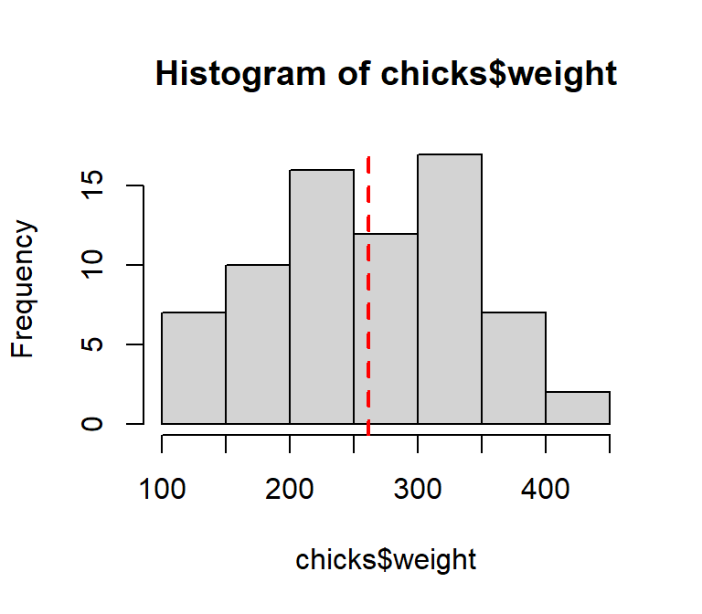

```r
hist(chicks$weight)
abline(v = mean(chicks$weight),
       col = 'red', lty = 2, lwd = 2) # vanity
```

## Exploratory graphs & data

Box plot `boxplot()`: central tendency of numeric ~ factor

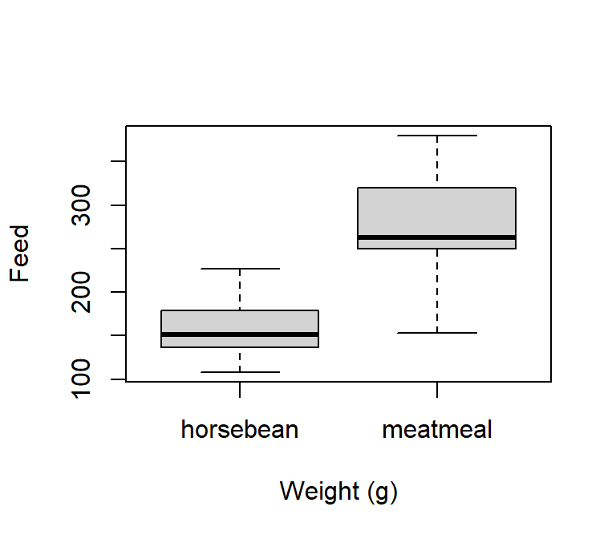

```r
select <- which(chicks$feed=='meatmeal' | chicks$feed=='horsebean')
boxplot(weight ~ feed, data = chicks[select, ],
        xlab='Weight (g)', ylab = 'Feed')
```

## Exploratory graphs & data

Scatterplot `plot()`: y ~ x of 2 numeric vars

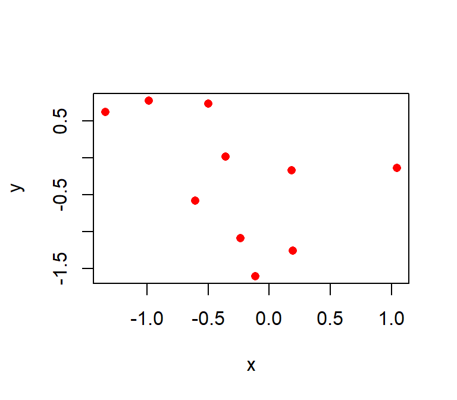

```r
x <- rnorm(10); y <- rnorm(10)
plot(y ~ x,
     col = 'red', pch = 16) # vanity
```

## (EDA) Exploratory Data Analysis

EDA:

- Begins every analysis in some form
- Informal, may be haphazard
- Testing assumptions (e.g. distributions)
- Information for the analyst, not others
- May or may not require reproducibility
- Prior to “formal analysis”

## (EDA) Exploratory Data Analysis

Formal analysis

## Statistical analysis plan

Best practice:

- **Hypothesis**, objective, claim
- **Specify statistical model**
- **Data collection methods**, sampling
- Identify **effect size**
- **Justify sample size**

## Statistical analysis plan

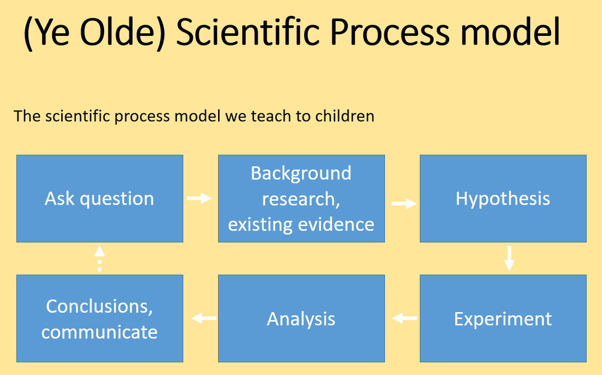

## Statistical analysis plan

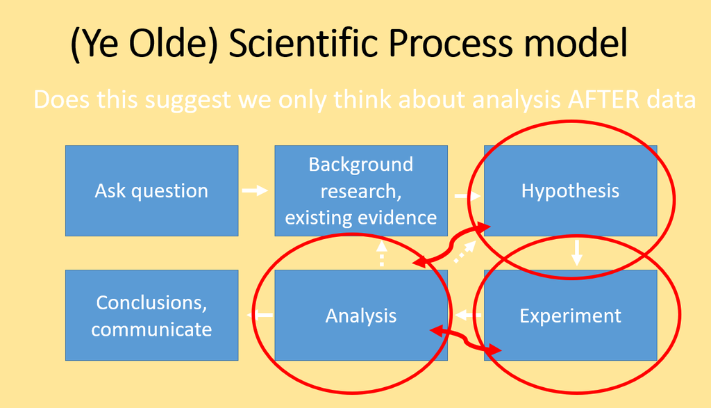

## Statistical analysis plan

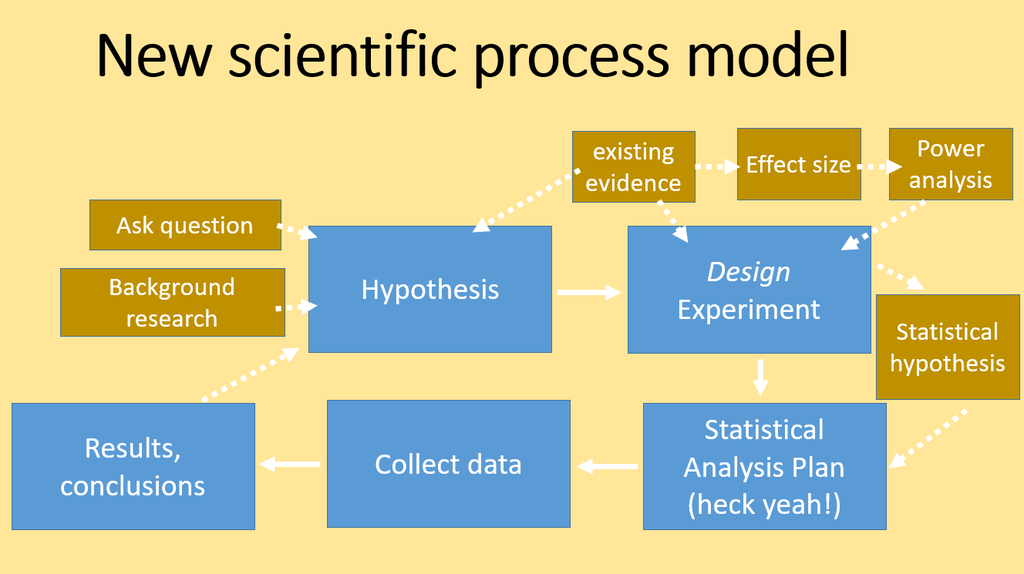

## Live coding

[figure not shown]